# automatization_notebook

2025-09-12

В данном задании вы будете использовать датасеты `dm.csv`, `vs.csv` и `lb.xlsx`.

# 1. Чтение и очистка данных

## 1.1. DM (Demographics)

Загрузите датасет `dm.csv` в переменную `dm` и выберите столбцы `USUBJID`, `SEX` и `ACTARM`.

Это датасет в широком формате: на каждого субъекта (`USUBJID`) должна приходиться только одна строка.

```r
dm <- read_csv2("data/raw/dm.csv")

dm <- dm %>%
  select(USUBJID, SEX, ACTARM)
```

## 1.2. VS (Vital Signs)

Загрузите датасет `vs.csv` в переменную `vs`.

Данные в длинном формате: на каждого субъекта (`USUBJID`) приходится несколько строк с разными измерениями.

Отфильтруйте измерения температуры тела на скрининге (`VSTESTCD` равен `TEMP`, `VISTINUM` равен `1`). Выберите столбец `USUBJID` и столбец `VSORRES` под именем `TEMP`.

```r
vs <- read_csv("data/raw/vs.csv")

vs <- vs %>%
  filter(VSTESTCD == "TEMP", VISITNUM == 1)

vs <- vs %>%
  select(USUBJID, TEMP = VSORRES)
```

Убедитесь, что в результате на каждого субъекта (`USUBJID`) приходится только одна строка.

## 1.3. LB (Laboratory Test Results)

Загрузите датасет `lb.xlsx` в переменную `lb`;

Данные в длинном формате: на каждого субъекта (`USUBJID`) приходится несколько строк с разными измерениями.

Отфильтруйте измерения кол-ва лейкоцитов на скрининге (`LBTESTCD` равен `WBC`, `VISTINUM` равен `1`). Выберите столбец `USUBJID` и столбец `LBORRES` под именем `WBC`.

```r
lb <- readxl::read_excel("data/raw/lb.xlsx")

lb <- lb %>%
  filter(LBTESTCD == "WBC", VISITNUM == 1)

lb <- lb %>%
  select(USUBJID, WBC = LBORRES)
```

Убедитесь, что теперь на каждого субъекта (`USUBJID`) приходится только одна строка.

# 2. Объединение данных

В переменных `dm`, `vs` и `lb` должно быть по 1 строке на 1 субъекта (`USUBJID`). Соедините их в один датасет `data` при помощи функции `left_join`. Уберите строки с пропущенными данными в столбцах `TEMP` и `WBC`.

```r
data <- dm %>%
  left_join(vs, join_by(USUBJID)) %>%
  left_join(lb, join_by(USUBJID))

data <- data %>%
  filter(!is.na(TEMP) & !is.na(WBC))
```

# 3. Дальнейшая очистка данных

```r
# перекодирование данных здесь

data <- data %>%
  mutate(TEMP = parse_number(str_replace(TEMP, ",", ".")))
```

```r
# перекодирование данных здесь

data <- data %>%
  mutate(WBC = as.numeric(str_replace(WBC, ",", ".")))
```

# 4. Визуализация

Сделайте боксплот для столбца, который импортировали вы:

- **Автор dm**: боксплот температуры тела (`TEMP`) в зависимости от пола (`SEX`)
- **Автор vs:** боксплот температуры тела (`TEMP`) в зависимости от группы (`ACTARM`)
- **Автор lb:** боксплот кол-ва лейкоцитов (`WBC`) в зависимости от группы (`ACTARM`)

‼️ Перекодирование данных выполните в общем чанке в главе 3 выше.

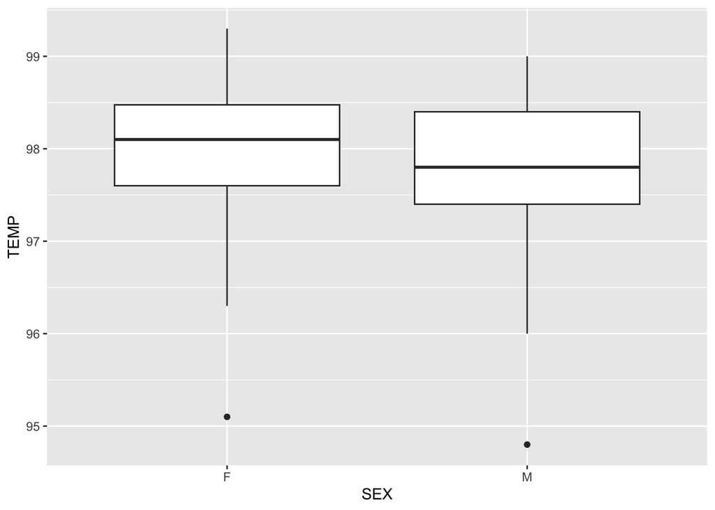

```r
ggplot(data, aes(SEX, TEMP)) +
  geom_boxplot()
```

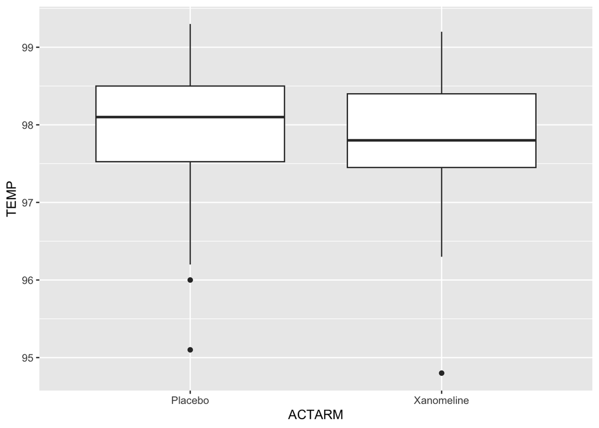

```r
ggplot(data, aes(ACTARM, TEMP)) +
  geom_boxplot()
```

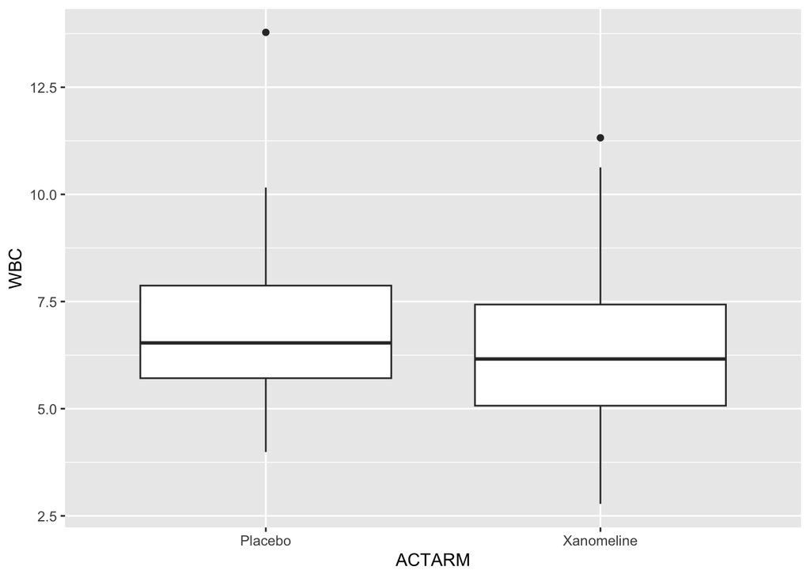

```r
ggplot(data, aes(ACTARM, WBC)) +
  geom_boxplot()
```

# Дополнительные задания

1. Перекодируйте пол из кодов `M`, `F` в подписи `Male`, `Female`. Постройте столбиковую диаграмму для пола в зависимости от группы (`ACTARM`) в том же чанке, что и боксплоты.
2. Перекодируйте градусы из шкалы Фаренгейта в шкалу Цельсия. Сделайте это в главе 3, в том же чанке, что и очистка данных. Подпишите оси соответствующих боксплотов.
3. Переведите боксплот количества лейкоцитов на логарифмическую шкалу. Используйте функцию scale_y_log10(). Подпишите ось Y, указав единицы измерения — 10^9/L.
4. Добавьте себя в список авторов в шапке файла. См. документацию к Rmarkdown по ссылке https://bookdown.org/yihui/rmarkdown-cookbook/multiple-authors.html)

# Домашнее задание

5. Добавьте в чат своей команды телеграм бота @octo8bot и настройте уведомления об изменениях в Pull Request